# Making maps using `geokz`-package

Alexander Rodionov

```r
library(geokz)
```

**`geokz`-package provides access to multiple dataset of different types and for different use. In this vignette we introduce the different datas and explain their use cases. Vignette *Making maps using {geokz}-package* provides multiple real-world examples of their usage.**

## Package installation

`geokz` can be installed from CRAN using

```r
# install from CRAN
install.packages("geokz")

# Install development version from GitHub
remotes::install_github("arodionoff/geokz")
```

## Administrative units level 1 keys

Kazakhstan is divided into 14 regions (Kazakh: облыстар/oblystar; singular: облыс/oblys; Russian: области/oblasti; singular: область/oblast’ ), the Capital - [Nur-Sultan](http://www.akorda.kz/ru/legal_acts/decrees/o-pereimenovanii-goroda-astany-stolicy-respubliki-kazahstan-v-gorod-nur-sultan-stolicu-respubliki-kazahstan) (formerly Astana) and 3 Cities of Republican Significance (Almaty, Shymkent and also Baikonyr, near is the World’s First spaceport).

```r
library(geokz)
library(dplyr)
library(sf)
IQR <- data(package = "geokz")
dplyr::as_tibble(IQR$results) %>%
  dplyr::select(Item, Title) %>%
    dplyr::filter(grepl("kaz_adm1_sf", Item))
```

```
#> # A tibble: 1 x 2
#>   Item        Title
#>   <chr>       <chr>
#> 1 kaz_adm1_sf ""
```

```r
names(geokz::kaz_adm1_sf)
```

```
#>  [1] "KATO"       "ADM0_EN"    "ADM0_KK"    "ADM0_RU"    "ADM0_PCODE"
#>  [6] "ADM1_EN"    "ADM1_KK"    "ADM1_RU"    "ADM1_PCODE" "ISO_3166_2"
#> [11] "geometry"
```

With these Oblast keys you can easily filter Oblasts for plotting or you can list different regional (Multi-Oblast) breakdowns.

```r
geokz::kaz_adm1_sf %>%
  sf::st_drop_geometry() %>%
    dplyr::count(ADM1_PCODE, ADM1_EN, ADM1_KK, ADM1_RU, ISO_3166_2)
```

```
#>    ADM1_PCODE           ADM1_EN                                  ADM1_KK
#> 1        KZ11            Akmola                            Ақмола
#> 2        KZ15            Aktobe                     Ақтөбе
#> 3        KZ19            Almaty                                   Алматы
#> 4        KZ23            Atyrau                                   Атырау
#> 5        KZ27   West Kazakhstan            Батыс Қазақстан
#> 6        KZ31            Jambyl                                   Жамбыл
#> 7        KZ35         Karagandy                  Қарағанды
#> 8        KZ39          Kostanay                          Қостанай
#> 9        KZ43         Kyzylorda                         Қызылорда
#> 10       KZ47         Mangystau                  Маңғыстау
#> 11       KZ55          Pavlodar                                 Павлодар
#> 12       KZ59  North Kazakhstan Солтүстiк Қазақстан
#> 13       KZ61         Turkestan                         Түркістан
#> 14       KZ63   East Kazakhstan     Шығыс Қазақстан
```

[output cut: 21 more lines]

`kaz_adm1_sf` keys are joined with the oblast spatial data (geographic features) by default, meaning that data returned by `get_kaz_oblasts_map()` can be aggregated as it is.

## Administrative units level 2 keys

Official administrative regions in Kazakhstan are based on rayons (the district units of principal units) or Administrative units level 2. From 2018 there are 216 rayons (equivalent territories, for example, related to city administrations - City of Oblast Significance and Rayons of Cities of Republican Significance) and the number has been increasing since the reorganization of Kazakhstan in 1997 through the division of districts.

Each rayons belongs to a higher level regional classifications such as regions (Oblast) or Administrative units level 1. `kaz_adm2_sf`-datasets are based on Kazakhstani administrative division [Statistical classification](https://stat.gov.kz/api/getFile/?docId=ESTAT274201)(2018 version) with few modification and provided on yearly basis.

Note, the large cities with more than 400 thousand inhabitants (now, Aktobe and Karaganda) also have regional divisions, but such districts are not considered separate administrative units of the 3 level, but are referred to the 3 level, like rural districts with 5-10 settlements.

```r
IQR <- data(package = "geokz")
dplyr::as_tibble(IQR$results) %>%
  dplyr::select(Item, Title) %>%
    dplyr::filter(grepl("kaz_adm2_sf", Item))
```

```
#> # A tibble: 1 x 2
#>   Item        Title
#>   <chr>       <chr>
#> 1 kaz_adm2_sf ""
```

Looking at the names of `kaz_adm2_sf` there is 15 different variables from each rayons

```r
names(geokz::kaz_adm2_sf)
```

```
#>  [1] "KATO"       "ADM0_EN"    "ADM0_KK"    "ADM0_RU"    "ADM0_PCODE"
#>  [6] "ADM1_EN"    "ADM1_KK"    "ADM1_RU"    "ADM1_PCODE" "ADM2_EN"
#> [11] "ADM2_KK"    "ADM2_RU"    "ADM2_PCODE" "ISO_3166_2" "geometry"
```

With these rayon keys you can easily aggregate rayons for plotting or you can list different regional (Oblast) breakdowns.

```r
geokz::kaz_adm2_sf %>%
  sf::st_drop_geometry() %>%
    dplyr::count(ADM1_PCODE, ADM1_EN, ADM1_KK, ADM1_RU, ISO_3166_2)
```

```
#>    ADM1_PCODE           ADM1_EN                                  ADM1_KK
#> 1        KZ11            Akmola                            Ақмола
#> 2        KZ15            Aktobe                     Ақтөбе
#> 3        KZ19            Almaty                                   Алматы
#> 4        KZ23            Atyrau                                   Атырау
#> 5        KZ27   West Kazakhstan            Батыс Қазақстан
#> 6        KZ31            Jambyl                                   Жамбыл
#> 7        KZ35         Karagandy                  Қарағанды
#> 8        KZ39          Kostanay                          Қостанай
#> 9        KZ43         Kyzylorda                         Қызылорда
#> 10       KZ47         Mangystau                  Маңғыстау
#> 11       KZ55          Pavlodar                                 Павлодар
#> 12       KZ59  North Kazakhstan Солтүстiк Қазақстан
#> 13       KZ61         Turkestan                         Түркістан
#> 14       KZ63   East Kazakhstan     Шығыс Қазақстан
```

[output cut: 21 more lines]

`kaz_adm2_sf` keys are joined with the rayon spatial data (geographic features) by default, meaning that data returned by `get_kaz_rayons_map()` can be aggregated as it is.

## Administrative units level 3 keys

In the Administrative units 3 level there are 47 cities of regional significance, 4 urban districts (2 each in the cities of regional significance Karaganda and Aktobe), 26 village administrations (akimats), 2283 rural district akimats and 82 rural akimats.

The coverage on Centers of Administrative units level 2 including the Capital Nur-Sultan (formerly Astana), 3 Cities of Republican Significance (Almaty, Shymkent and also Baikonur or Baykonyr, near is the World’s First Spaceport) and all center of Oblasts (the principal units of a country) of Kazakhstan (2019 version).

Looking at the names of kaz_cnt1_sf there is 15 different variables from each centers.

```r
names(geokz::kaz_cnt1_sf)
```

```
#>  [1] "KATO"       "ADM0_EN"    "ADM0_KK"    "ADM0_RU"    "ADM0_PCODE"
#>  [6] "ADM1_EN"    "ADM1_KK"    "ADM1_RU"    "ADM1_PCODE" "TYPE_CNT1"
#> [11] "ISO_3166_2" "NAME_EN"    "NAME_KK"    "NAME_RU"    "geometry"
```

## Spatial data

Spatial data is provided as administrative regions (polygons) and administrative district (polygons) and region centers (points).

The **Default Projection** uses [A Lambert Conformal Conic (LCC)](https://proj.org/operations/projections/lcc.html) with *Krasovsky 1940 ellipsoid* and *First standard parallel* - 45 N, *Second standard parallel* - 51 N, *Longitude of projection center* - 67 E, *Latitude of projection center* - 48 N.

### Oblast borders

Oblast and Cities of Republican Significance borders are provided yearly from 2018.

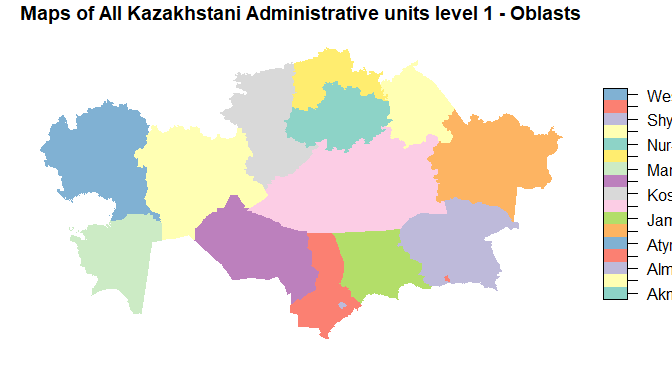

```r
rayons <- get_kaz_oblasts_map()
plot(rayons["ADM1_EN"], border = NA,
     main = "Maps of All Kazakhstani Administrative units level 1 - Oblasts")
```

Source: [The Centre for Humanitarian Data](https://data.humdata.org/dataset/kazakhstan-administrative-boundaries-taxonomy) is managed by the United Nations Office for the Coordination of Humanitarian Affairs (OCHA).

Use can use names of Regions in different languages (English, Russian or Kazakh) for filtering and binding geographic features. Non-latin characters you can convert into Unicode (not ASCII-printable) code points, for example, `cat(stringi::stri_escape_unicode("Нұр-Сұлтан (қала)"))`.

```r
x <- "\u041d\u04b1\u0440-\u0421\u04b1\u043b\u0442\u0430\u043d (\u049b\u0430\u043b\u0430)"
get_kaz_oblasts_map(ADM1_KK = x) %>%
  dplyr::select("KATO", "ADM1_EN", "ADM1_KK", "ADM1_RU", "ADM1_PCODE", "ISO_3166_2") %>%
    sf::st_drop_geometry() %>%
      knitr::kable(., caption = "Administrative unit level 1 - \nThe Capital (kaz. <b>'\u041d\u04b1\u0440-\u0421\u04b1\u043b\u0442\u0430\u043d (\u049b\u0430\u043b\u0430)'</b>")
```

Administrative unit level 1 - The Capital (kaz. **‘Нұр-Сұлтан (қала)’**

|  | KATO | ADM1_EN | ADM1_KK | ADM1_RU | ADM1_PCODE | ISO_3166_2 |
| --- | --- | --- | --- | --- | --- | --- |
| 15 | 710000000 | Nur-Sultan (city) | Нұр-Сұлтан (қала) | Нур-Султан | KZ71 | KZ-AST |

### Rayon borders

Rayon and Cities of Republican Significance borders are provided by 2018 version.

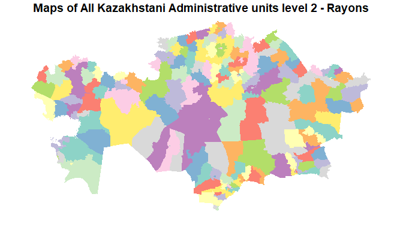

```r
rayons <- get_kaz_rayons_map()
plot(rayons["ADM2_EN"], border = NA,
     main = "Maps of All Kazakhstani Administrative units level 2 - Rayons")
```

Source: [The Centre for Humanitarian Data](https://data.humdata.org/dataset/kazakhstan-administrative-boundaries-taxonomy) is managed by the United Nations Office for the Coordination of Humanitarian Affairs (OCHA). The borders of districts were corrected by Alexander Rodionov in [QGIS](https://qgis.org/).

### Centers of Administrative units 1 Level

Oblast Centers and Cities of Republican Significance borders are provided yearly from 2019 after renaming Astana into Nur-Sultan.

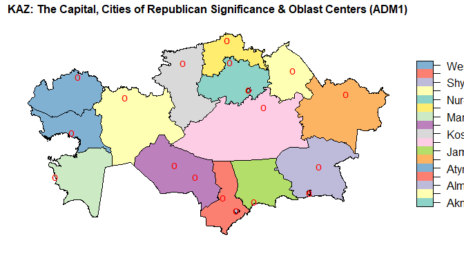

```r
kaz_cnt1_sf <-
  sf::st_transform(x = kaz_cnt1_sf,
                   crs = "+proj=lcc +lon_0=67 +lat_1=45 +lat_2=51 +ellps=krass")

kaz_cnt1_sf$punch <- (5 - kaz_cnt1_sf$TYPE_CNT1)

# adding to a plot of an sf object only works when using reset=FALSE in the first plot
plot(x = get_kaz_oblasts_map()["ADM1_EN"], reset = FALSE, cex.main = 1.0,
     main = "KAZ: The Capital, Cities of Republican Significance & Oblast Centers (ADM1)")
plot(kaz_cnt1_sf["KATO"], col = "red", pch = "o", add = TRUE)
```

The cities mapped by Alexander Rodionov in [QGIS](https://qgis.org/).

## Use several packages for mapping (**{tmap}**, **{ggplot2}**, **{leaflet}**)

### Package **{tmap}**: Joining attribute data with geokz data

This vignettes provides few examples on how to join attribute data from common sources of attribute data. Here we are using data from two different sources of [The Bureau of National Statistics](https://stat.gov.kz/about/general/regulation) of the Agency for Strategic Planning and Reforms of the Republic of Kazakhstan: [the Population of the Republic of Kazakhstan](https://stat.gov.kz/api/getFile/?docId=ESTAT431598) and the Area of [Kazakhstani Regions](https://en.wikipedia.org/wiki/Regions_of_Kazakhstan). Third is [Zones of Kazakhstan are distinguished according to natural conditions](https://adilet.zan.kz/rus/docs/V2000021691#z70).

#### Population Density of Kazakhstan (2021)

```r
library(geokz)
library(dplyr)
library(knitr)

Population_Density_df <-
  data.frame(
    ISO_3166_2 = c("KZ-AKM", "KZ-AKT", "KZ-ALM", "KZ-ATY", "KZ-VOS", "KZ-ZHA", "KZ-KAR", "KZ-KUS", "KZ-KZY", "KZ-MAN", "KZ-SEV", "KZ-PAV", "KZ-YUZ", "KZ-ZAP", "KZ-AST", "KZ-ALA", "KZ-SHY"),
    Region = c("Akmola Region", "Aktobe Region", "Almaty Region", "Atyrau Region", "East Kazakhstan Region", "Jambyl Region", "Karaganda Region", "Kostanay Region", "Kyzylorda Region", "Mangystau Region", "North Kazakhstan Region", "Pavlodar Region", "Turkistan Region", "West Kazakhstan Region", "Nur-Sultan", "Almaty", "Shymkent"),
    Area = c(146219, 300629, 223924, 118631, 283226, 144264, 427982, 196001, 226019, 165642, 97993, 124800, 117249, 151339, 710, 319, 1170),
    Population = c(735481, 893669, 2077656, 657118, 661172, 1139151, 1375788, 864529, 814461, 719559, 751011, 543679, 2044551, 1363656, 1184469, 1977011, 1074167)
) %>%
  dplyr::mutate(Population_Density = round( Population / Area, 1))

knitr::kable(Population_Density_df, caption = 'Demographic statistics of <b>Kazakhstan</b>',
             format.args = list(big.mark = ' '))
```

Demographic statistics of **Kazakhstan**

| ISO_3166_2 | Region | Area | Population | Population_Density |
| --- | --- | --- | --- | --- |
| KZ-AKM | Akmola Region | 146 219 | 735 481 | 5.0 |
| KZ-AKT | Aktobe Region | 300 629 | 893 669 | 3.0 |
| KZ-ALM | Almaty Region | 223 924 | 2 077 656 | 9.3 |
| KZ-ATY | Atyrau Region | 118 631 | 657 118 | 5.5 |
| KZ-VOS | East Kazakhstan Region | 283 226 | 661 172 | 2.3 |
| KZ-ZHA | Jambyl Region | 144 264 | 1 139 151 | 7.9 |
| KZ-KAR | Karaganda Region | 427 982 | 1 375 788 | 3.2 |
| KZ-KUS | Kostanay Region | 196 001 | 864 529 | 4.4 |
| KZ-KZY | Kyzylorda Region | 226 019 | 814 461 | 3.6 |
| KZ-MAN | Mangystau Region | 165 642 | 719 559 | 4.3 |
| KZ-SEV | North Kazakhstan Region | 97 993 | 751 011 | 7.7 |
| KZ-PAV | Pavlodar Region | 124 800 | 543 679 | 4.4 |
| KZ-YUZ | Turkistan Region | 117 249 | 2 044 551 | 17.4 |
| KZ-ZAP | West Kazakhstan Region | 151 339 | 1 363 656 | 9.0 |
| KZ-AST | Nur-Sultan | 710 | 1 184 469 | 1 668.3 |
| KZ-ALA | Almaty | 319 | 1 977 011 | 6 197.5 |
| KZ-SHY | Shymkent | 1 170 | 1 074 167 | 918.1 |

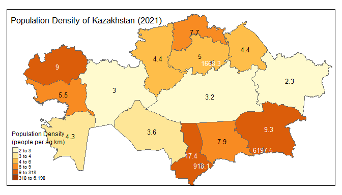

```r
dplyr::inner_join( x = get_kaz_oblasts_map(),
                   y = Population_Density_df[, c("ISO_3166_2", "Population_Density")],
                   by = c("ISO_3166_2" = "ISO_3166_2") ) %>%
  tmap::qtm(
    shp = .,
    fill = "Population_Density",
    fill.n = 6,
    fill.style = "quantile",
    fill.text  = "Population_Density",
    fill.title = "Population Density \n(people per sq.km)",
    text = "Population_Density",
    title = "Population Density of Kazakhstan (2021)",
    format = "World"
    )
```

#### Zones are distinguished according to natural conditions

The territory of Kazakhstan is located in four climatic zones - forest-steppe, steppe, semi-desert and desert. The presence of mountains in the south and east of the country leads to the emergence of the allocation of special mountainous regions, significantly different from the surrounding area. So on the territory of the Republic **6** zones are distinguished according to natural conditions: Steppe (1), Dry-steppe (2), Foothill-desert-steppe (3), Desert (4), South Siberian mountain and foothill (5), Semi-desert (6).

```r
data(natural_zones)

natural_zones %>%
  dplyr::count(ZONE_EN) %>%
    dplyr::bind_rows(., data.frame( ZONE_EN = "TOTAL", n = nrow(natural_zones))) %>%
      knitr::kable(.,
         caption = "Administrative units level 2 by Zones according to <b>natural conditions</b>",
         format.args = list(big.mark = ' '))
```

Administrative units level 2 by Zones according to **natural conditions**

| ZONE_EN | n |
| --- | --- |
| Steppe | 40 |
| Dry-steppe | 52 |
| Foothill-desert-steppe | 57 |
| Desert | 29 |
| South Siberian mountain and foothill | 9 |
| Semi-desert | 29 |
| TOTAL | 216 |

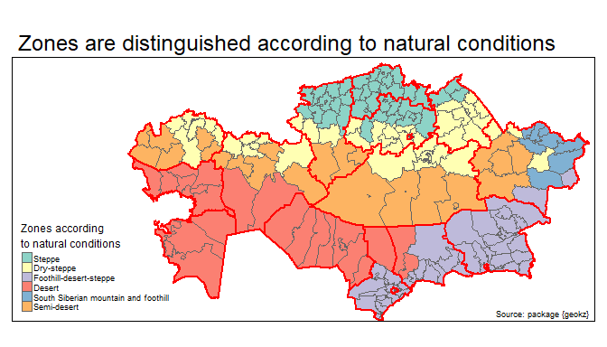

```r
dplyr::inner_join( x = get_kaz_rayons_map(),
                   y = natural_zones[, c("ADM2_PCODE", "ZONE_EN")],
                   by = c("ADM2_PCODE" = "ADM2_PCODE") ) %>%
tmap::tm_shape(shp = .) +
  tmap::tm_polygons(
    col = "ZONE_EN",
    title = "Zones according \nto natural conditions"
  ) +
tmap::tm_shape(shp = get_kaz_oblasts_map()) +
  tmap::tm_borders(col = "red", lwd = 3) +
tmap::tm_format(format = 'World_wide') +
tmap::tm_layout(main.title = "Zones are distinguished according to natural conditions") +
tmap::tm_credits('Source: package {geokz}', position = c('right', 'BOTTOM'))
```

However even such a division adopted by the *Ministry of Agriculture* does not reflect the presence of desert and foothill-desert lands with a subtropical climate, which occupy up to [8% of the country’s area](https://ecogosfond.kz/wp-content/uploads/2018/03/NDSOS_2011-2014.pdf).

#### Torgay Oblast is disbanded Region

[Torgay Oblast](https://en.wikipedia.org/wiki/Torgay_Region) is disbanded Region of the Kazakh Soviet Socialist Republic from 1970 to 1988 and of independent Kazakhstan and from 1990 to 1997.

Unfortunetely, simultaneous use of several types of geographic features codes or names in different languages **is not allowed**.

Fortunetely, Simultaneous use of several types of International & National codes or names in different languages **is allowed** with **binding geographic features**.

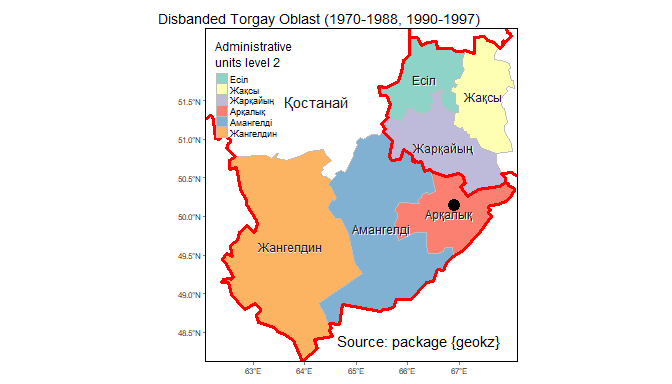

```r
Torgay_Region <-
  get_kaz_rayons_map(ADM2_EN = c(
    "Esil",
    "Zhaksy",
    "Zharkain")) %>%
  dplyr::filter(ADM1_EN == "Akmola") %>%  # There are three rayons named Esil by Esil (Ishim) river
  dplyr::bind_rows(
    get_kaz_rayons_map(ADM2_PCODE = c(
      "KZ391600",                         # Arkalyk city was a Center of Torgay Oblast
      "KZ393400",                         # Amangeldi rayon
      "KZ394200")                         # Zhangeldi rayons
      )
  ) %>%
  dplyr::mutate(ADM2_EN = factor(ADM2_EN, levels = ADM2_EN))

center_sf <-
  data.frame(
    NAME = c("Arkalyk"),
    BRANCH = c("The Center"),
    LINK = c("https://en.wikipedia.org/wiki/Arkalyk"),
    LAT = c(50.24861),
    LON = c(66.91139)
  ) %>%
  sf::st_as_sf(
    coords = c("LON", "LAT"), # columns with geometry by x - "LON" and y - "LAT"
    crs = "+proj=longlat +datum=WGS84"
  )

to_bb <-
  Torgay_Region %>%
  sf::st_bbox() %>%
  sf::st_as_sfc() %>%
  sf::st_buffer(dist = 50000)

tmap::tm_shape(Torgay_Region) +
  tmap::tm_polygons(
    col = "ADM2_EN",
    border.col = "grey",
    title = "Administrative \nunits level 2",
    labels = Torgay_Region$ADM2_KK
  ) +
  tmap::tm_text("ADM2_KK", col = "gray10", size = 0.9, shadow = TRUE) +
tmap::tm_shape(
  shp  = get_kaz_oblasts_map(),
  bbox = to_bb
  ) +
  tmap::tm_borders(
    col = "red",
    lwd = 4
  ) +
  tmap::tm_text("ADM1_KK", col = "gray10", size = 1.2, shadow = TRUE) +
tmap::tm_shape(center_sf) +
  tmap::tm_dots(size = 1) +
tmap::tm_graticules(lines = FALSE) +
  tmap::tm_format(format = 'World') +
  tmap::tm_layout(
    main.title = "Disbanded Torgay Oblast (1970-1988, 1990-1997)",
    main.title.size = 0.9,
    legend.position = c("left", "top")
  ) +
  tmap::tm_credits('Source: package {geokz}', position = c('right', 'bottom'), size = 1.2)
```

#### Interactive map using {tmap} package in **view** mode

See use {tmap} & {leaflet} packages for draw of Interactive Maps as `sf` objects.

### Package {ggplot2}: Flexibility in each of the layers and many aspects of visualisation

#### Kazakhstan: Administrative units level 1 (Oblasts & Cities of Republican Significance)

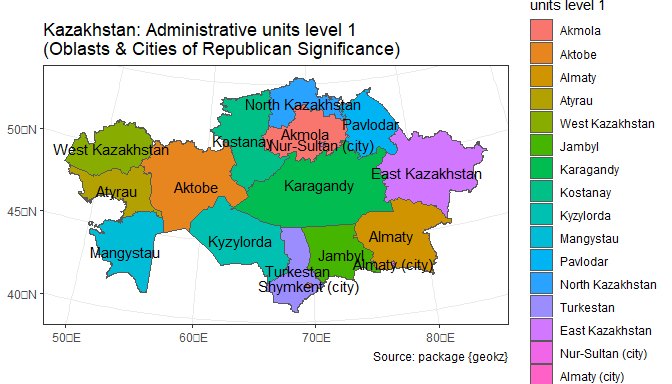

```r
library(ggplot2)
library(dplyr)

get_kaz_oblasts_map() %>%
  dplyr::mutate(ADM1_EN = factor(ADM1_EN, levels = ADM1_EN)) %>%
  ggplot2::ggplot(data = .) +
    ggplot2::geom_sf(mapping = ggplot2::aes(fill = ADM1_EN)) +  # forcats::fct_inorder(ADM1_EN)
    ggplot2::geom_sf_text(mapping = ggplot2::aes(label = ADM1_EN)) +
    ggplot2::theme_bw() +
    ggplot2::guides(fill = ggplot2::guide_legend(title = "Administrative \nunits level 1")) +
    ggplot2::labs(title = "Kazakhstan: Administrative units level 1
(Oblasts & Cities of Republican Significance)",
      x = NULL,
      y = NULL,
      caption = "Source: package {geokz}"
    )
```

#### Kazakhstan: Mangystau Oblast (Rayons & Cities of Oblast Significance)

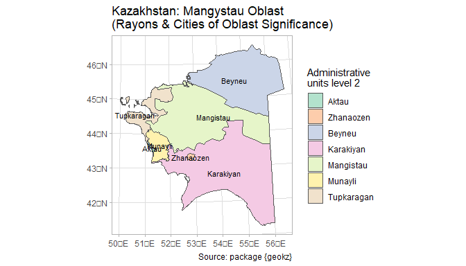

```r
library(dplyr)
library(ggplot2)
library(RColorBrewer)

kaz_adm2_sf %>%
  dplyr::filter(ADM1_EN =="Mangystau") %>%
  dplyr::mutate(ADM2_EN = factor(ADM2_EN, levels = ADM2_EN)) %>%
  ggplot2::ggplot(data = .) +
    ggplot2::geom_sf(mapping = ggplot2::aes(fill = ADM2_EN)) +   # forcats::fct_inorder(ADM2_EN)
    ggplot2::geom_sf_text(
      mapping = ggplot2::aes(label = ADM2_EN),
      size = 3
      ) +
    ggplot2::coord_sf(crs=2499) + # Pulkovo 1942 / Gauss-Kruger CM 51E. See <https://epsg.io/2499>.
    ggplot2::scale_fill_brewer(palette = "Pastel2") +  # uses library(RColorBrewer)
    ggplot2::theme_light() +
    ggplot2::guides(fill = ggplot2::guide_legend(title = "Administrative \nunits level 2")) +
    ggplot2::labs(title = "Kazakhstan: Mangystau Oblast
(Rayons & Cities of Oblast Significance)",
      x = NULL,
      y = NULL,
      caption = "Source: package {geokz}"
    )
```

#### Kazakhstan: Kyzylorda Oblast (Administrative Center, Rayons & City of Republican Significance)

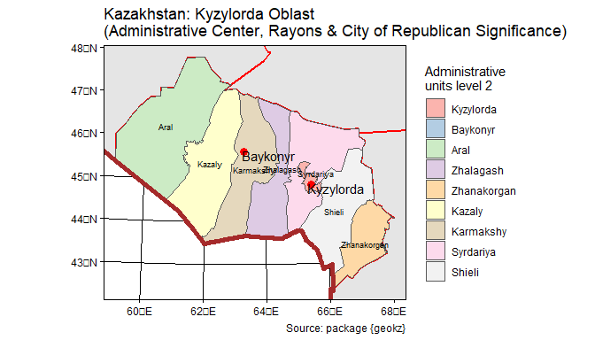

```r
library(dplyr)
library(sf)
library(ggplot2)

ko_bb <-
  dplyr::filter(kaz_adm1_sf, ADM1_EN == 'Kyzylorda') %>%
  sf::st_transform(crs = 2501) %>% # Pulkovo 1942 / Gauss-Kruger CM 63E. See <https://epsg.io/2501>.
  sf::st_bbox() %>%
  sf::st_as_sfc() %>%
  sf::st_buffer(dist = 30000)

kaz_adm2_sf %>%
  dplyr::filter(ADM1_EN =="Kyzylorda") %>%
  dplyr::mutate(ADM2_EN = factor(ADM2_EN, levels = ADM2_EN)) %>%
  ggplot2::ggplot(data = .) +
    ggplot2::geom_sf(                                           # Boundaries of Kazakhstani Oblasts
      data  = sf::st_geometry(kaz_adm1_sf),
      color = "red",
      size  = 1
    ) +
    ggplot2::geom_sf(                                           # Rayons of Kyzylorda Oblasts
      mapping = ggplot2::aes(fill = ADM2_EN)
      ) +  # forcats::fct_inorder(ADM2_EN)
    ggplot2::geom_sf_text(                                      # Labels of Rayons
      data = dplyr::filter(kaz_adm2_sf, (ADM1_EN == 'Kyzylorda' &
                              magrittr::and(ADM2_EN != "Kyzylorda", ADM2_EN != "Baykonyr"))),
      mapping = ggplot2::aes(label = ADM2_EN),
      size = 2.5
    ) +
    ggplot2::scale_fill_brewer(palette = "Pastel1") +
    ggplot2::geom_sf(                     # Administrative Center & City of Republican Significance
      data  = dplyr::filter(kaz_cnt1_sf, ADM1_EN == 'Kyzylorda'),
      size = 3,
      col = "red",
      shape = 19
    ) +
    ggplot2::geom_sf_text(                                      # Labels of Cities
      data  = dplyr::filter(kaz_cnt1_sf, ADM1_EN == 'Kyzylorda'),
      mapping = ggplot2::aes(label = NAME_EN),
      nudge_x = 65000,
      nudge_y = -9000,
      size = 4
    ) +
    ggplot2::geom_sf(                                           # Boundaries of Kazakhstan
      data  = sf::st_geometry(kaz_adm0_sf),
      alpha  = 0,
      color = "brown",
      size  = 2
    ) +
  # Set new Coordinate System: Pulkovo 1942 / Gauss-Kruger CM 63E. See <https://epsg.io/2501>.
    ggplot2::coord_sf(xlim = c(sf::st_bbox(ko_bb)$xmin, sf::st_bbox(ko_bb)$xmax),
                      ylim = c(sf::st_bbox(ko_bb)$ymin, sf::st_bbox(ko_bb)$ymax),
                      crs = 2501, expand = FALSE) +
    ggplot2::theme_linedraw() +
    ggplot2::guides(fill = ggplot2::guide_legend(title = "Administrative \nunits level 2")) +
    ggplot2::labs(title = "Kazakhstan: Kyzylorda Oblast
(Administrative Center, Rayons & City of Republican Significance)",
      x = NULL,
      y = NULL,
      caption = "Source: package {geokz}"
      )
```

### Package {leaflet}: Interactive map widget using **htmlwidgets**

#### Interactive Map of Kazakhstan with the Capitals

See use {leaflet} package for draw of Interactive Maps as `sf` objects.

#### Interactive Map of Kazakhstan with Rayons

See use {leaflet} package for draw of Interactive Maps as `sf` objects.

#### Interactive map of Kazakhstan with Region hyperlinks

You can create Interactive Maps with hyperlinks to Wikipedia articles about Kazakhstani Regions. Basemap can be varied from a list of [providers](https://leaflet-extras.github.io/leaflet-providers/preview/).

```r
  library(leaflet)
  library(magrittr)

  urls <-
    c("Akmola_Region", "Aktobe_Region", "Almaty_Region", "Atyrau_Region", "West_Kazakhstan_Region",
      "Jambyl_Region" , "Karaganda_Region", "Kostanay_Region", "Kyzylorda_Region",
      "Mangystau_Region", "Pavlodar_Region", "North_Kazakhstan_Region", "Turkistan_Region",
      "East_Kazakhstan_Region", "Nur-Sultan", "Almaty", "Shymkent")

  leaflet::leaflet() %>%
    leaflet::addProviderTiles(provider = "Esri.WorldPhysical") %>%
    leaflet::addPolygons(
      data = sf::st_zm(geokz::kaz_adm1_sf, geometry),
      weight = 1,
      color = "darkred",
      fillColor = "coral",
      fillOpacity = 0.3,
      smoothFactor = 0.5,
      popup = ~paste0("Region: ", '<a href = "https://en.wikipedia.org/wiki/', urls, '"> ',
                      ADM1_EN, "</a><br>", "KATO: ", KATO, "<br>", "ISO 3166-2: ", ISO_3166_2),
      label = ~paste(ADM1_EN, ":", ADM1_PCODE),
      labelOptions = labelOptions(direction = "auto")
    ) %>%
    leaflet::addCircleMarkers(
      data = geokz::kaz_cnt1_sf,
      color = "brown",
      radius = 3,
      label = ~paste0("Center of ", ADM1_EN,": ", NAME_EN)
    )
```

[interactive chart not shown]